# Data Preparation — Final State

Occurrence data pipeline for SDM of Neotropical vascular epiphytes

Author

Maria Judith Carmona Higuita

Published

May 12, 2026

# 1 Overview

This document summarises the complete occurrence data preparation pipeline for the analysis of endemism hotspots of Neotropical vascular epiphytes under climate and land-use change scenarios. All steps are fully reproducible via the scripts in `scripts/01_*.R`.

```r
tibble(
  Step = c(
    "Raw database (EpIG-DB 2.0 + GBIF)",
    "01_01 — Coordinate uncertainty filter",
    "01_02 — Spatial thinning (0.25°)",
    "01_03 — EOO + endemism classification"
  ),
  Records = c(
    format(nrow(db_strict),  big.mark = ","),
    format(nrow(db_unc),     big.mark = ","),
    format(nrow(db_thinned), big.mark = ","),
    "—"
  ),
  Species = c(
    format(n_distinct(db_strict$scientificName),  big.mark = ","),
    format(n_distinct(db_unc$scientificName),     big.mark = ","),
    format(n_distinct(db_thinned$scientificName), big.mark = ","),
    format(nrow(spp_flags), big.mark = ",")
  ),
  Notes = c(
    "Post-cleaning: families + species excluded",
    "Keep NA uncertainty OR <= 27,500 m",
    "1 record per species per 0.25° cell; seed = 123",
    "EOO calculated with ConR (convex hull, exclude.area = FALSE)"
  )
) %>%
  kable(caption = "Data preparation pipeline summary") %>%
  kable_styling(full_width = FALSE)
```

Data preparation pipeline summary

| Step | Records | Species | Notes |
| --- | --- | --- | --- |
| Raw database (EpIG-DB 2.0 + GBIF) | 864,624 | 14,979 | Post-cleaning: families + species excluded |
| 01_01 — Coordinate uncertainty filter | 845,776 | 14,894 | Keep NA uncertainty OR <= 27,500 m |
| 01_02 — Spatial thinning (0.25°) | 350,059 | 14,894 | 1 record per species per 0.25° cell; seed = 123 |
| 01_03 — EOO + endemism classification | — | 14,909 | EOO calculated with ConR (convex hull, exclude.area = FALSE) |

# 2 Step 01_01 — Coordinate Uncertainty Filter

Records were retained where `coordinateUncertaintyInMeters` was `NA` (unknown precision, majority of historical herbarium specimens) or ≤ 27,500 m (equivalent to the 0.25° working resolution at the equator). Records with uncertainty > 27,500 m were removed because the true location could fall in a different grid cell at the modelling resolution.

**Decision rationale:** Excluding NA uncertainty records would introduce a temporal bias toward post-2000 collections and reduce taxonomic coverage of historically collected taxa. At 0.25° resolution, the cost of retaining imprecise records is lower than at finer scales.

```r
unc_summary %>%
  arrange(desc(n_removed)) %>%
  head(15) %>%
  kable(
    caption = "Top 15 families by records removed (coordinate uncertainty filter)",
    digits  = 1
  ) %>%
  kable_styling(full_width = FALSE)
```

Top 15 families by records removed (coordinate uncertainty filter)

| family | n_before | n_after | n_removed | pct_removed |
| --- | --- | --- | --- | --- |
| Orchidaceae | 160294 | 157113 | 3181 | 2.0 |
| Araceae | 103003 | 100447 | 2556 | 2.5 |
| Bromeliaceae | 144685 | 142392 | 2293 | 1.6 |
| Polypodiaceae | 98118 | 95987 | 2131 | 2.2 |
| Hymenophyllaceae | 32021 | 30934 | 1087 | 3.4 |
| Piperaceae | 56706 | 55621 | 1085 | 1.9 |
| Aspleniaceae | 35189 | 34125 | 1064 | 3.0 |
| Dryopteridaceae | 32895 | 32279 | 616 | 1.9 |
| Ericaceae | 21717 | 21209 | 508 | 2.3 |
| Melastomataceae | 19094 | 18591 | 503 | 2.6 |
| Gesneriaceae | 24094 | 23596 | 498 | 2.1 |
| Lycopodiaceae | 10665 | 10261 | 404 | 3.8 |
| Solanaceae | 12888 | 12577 | 311 | 2.4 |
| Blechnaceae | 9927 | 9676 | 251 | 2.5 |
| Nephrolepidaceae | 5481 | 5257 | 224 | 4.1 |

```r
tibble(
  Metric = c("Records before filter", "Records removed",
             "Pct removed", "Records retained", "Species retained"),
  Value  = c(
    format(nrow(db_strict),                        big.mark = ","),
    format(nrow(db_strict) - nrow(db_unc),         big.mark = ","),
    paste0(round((nrow(db_strict) - nrow(db_unc)) /
                   nrow(db_strict) * 100, 1), "%"),
    format(nrow(db_unc),                           big.mark = ","),
    format(n_distinct(db_unc$scientificName),      big.mark = ",")
  )
) %>%
  kable(caption = "Uncertainty filter: overall summary") %>%
  kable_styling(full_width = FALSE)
```

Uncertainty filter: overall summary

| Metric | Value |
| --- | --- |
| Records before filter | 864,624 |
| Records removed | 18,848 |
| Pct removed | 2.2% |
| Records retained | 845,776 |
| Species retained | 14,894 |

# 3 Step 01_02 — Spatial Thinning

Occurrences were thinned to one record per species per 0.25° grid cell (set.seed = 123). This removes spatial redundancy introduced by repeated sampling at the same or nearby locations, and ensures that each grid cell contributes at most one data point per species during model calibration.

```r
tibble(
  Metric = c("Records before thinning", "Records removed",
             "Pct removed", "Records retained", "Species retained"),
  Value  = c(
    format(nrow(db_unc),                           big.mark = ","),
    format(nrow(db_unc) - nrow(db_thinned),        big.mark = ","),
    paste0(round((nrow(db_unc) - nrow(db_thinned)) /
                   nrow(db_unc) * 100, 1), "%"),
    format(nrow(db_thinned),                       big.mark = ","),
    format(n_distinct(db_thinned$scientificName),  big.mark = ",")
  )
) %>%
  kable(caption = "Spatial thinning: overall summary") %>%
  kable_styling(full_width = FALSE)
```

Spatial thinning: overall summary

| Metric | Value |
| --- | --- |
| Records before thinning | 845,776 |
| Records removed | 495,717 |
| Pct removed | 58.6% |
| Records retained | 350,059 |
| Species retained | 14,894 |

The high removal rate (58.6%) reflects the well-known sampling bias of epiphyte occurrence data toward accessible localities (roadsides, biological stations, botanical gardens), consistent with Svahnström et al. (2025).

## 3.1 Record classes post-thinning

Species were classified by their number of thinned records to determine the appropriate modelling approach:

```r
record_class %>%
  kable(
    caption = paste0("Species by record class after thinning to 0.25°.",
                     " MIN_OCC = 5, ESM_THRESHOLD = 25"),
    digits  = 1
  ) %>%
  kable_styling(full_width = FALSE)
```

Species by record class after thinning to 0.25°. MIN_OCC = 5, ESM_THRESHOLD = 25

| record_class | n_species | pct_species |
| --- | --- | --- |
| <5 (exclude) | 7054 | 47.3 |
| 5-24 (ESM) | 5031 | 33.7 |
| >=25 (SDM) | 2824 | 18.9 |

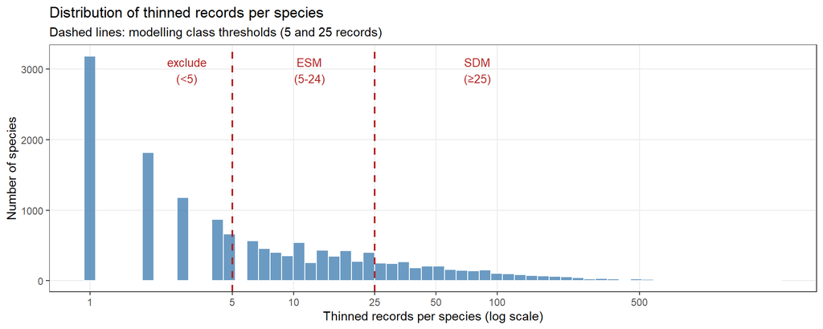

```r
species_summary %>%
  ggplot(aes(x = n_records)) +
  geom_histogram(bins = 60, fill = "steelblue", colour = "white",
                 alpha = 0.8) +
  geom_vline(xintercept = c(5, 25), linetype = "dashed",
             colour = "firebrick", linewidth = 0.8) +
  scale_x_log10(
    breaks = c(1, 5, 10, 25, 50, 100, 500),
    labels = c(1, 5, 10, 25, 50, 100, 500)
  ) +
  annotate("text", x = 3,  y = Inf, label = "exclude\n(<5)",
           vjust = 1.5, size = 3.5, colour = "firebrick") +
  annotate("text", x = 12, y = Inf, label = "ESM\n(5-24)",
           vjust = 1.5, size = 3.5, colour = "firebrick") +
  annotate("text", x = 80, y = Inf, label = "SDM\n(≥25)",
           vjust = 1.5, size = 3.5, colour = "firebrick") +
  labs(
    title    = "Distribution of thinned records per species",
    subtitle = "Dashed lines: modelling class thresholds (5 and 25 records)",
    x        = "Thinned records per species (log scale)",
    y        = "Number of species"
  ) +
  theme_bw() +
  theme(panel.grid.minor = element_blank())
```

Nearly half of all species (47.3%) have fewer than 5 thinned records and cannot be modelled with standard SDM approaches. This is consistent with the high prevalence of rarity in vascular epiphytes documented by Svahnström et al. (2025), who found that ~45% of epiphyte species have EOO < 20,000 km².

# 4 Step 01_03 — EOO Calculation and Endemism Classification

## 4.1 EOO calculation

Extent of Occurrence (EOO) was calculated using the minimum convex hull method (ConR v2.1; `EOO.computing()`), following IUCN Red List guidelines v4.0. `exclude.area = FALSE` was used per IUCN recommendation:

> *“The EOO should not be adjusted to exclude obviously unsuitable areas”* (IUCN 2022, Guidelines for Using the IUCN Red List Categories and Criteria)

EOO was calculated at 0.25° resolution (consistent with modelling resolution) on `db_thinned_025`. Species with fewer than 3 unique coordinate pairs received EOO = NA.

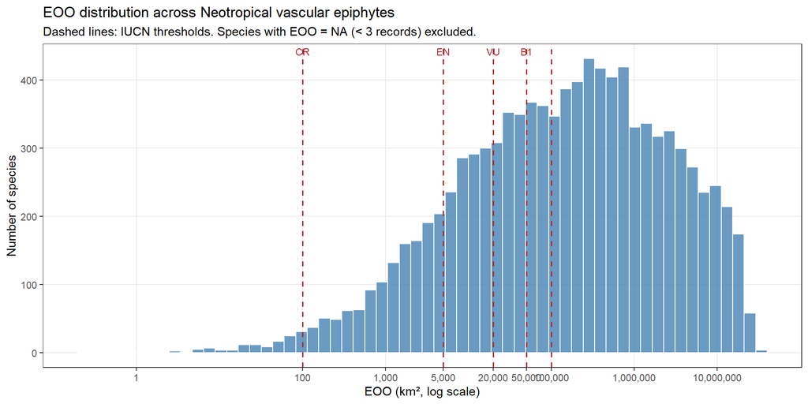

```r
eoo_all %>%
  filter(!is.na(EOO_km2), EOO_km2 > 0) %>%
  ggplot(aes(x = EOO_km2)) +
  geom_histogram(bins = 60, fill = "steelblue", colour = "white",
                 alpha = 0.8) +
  geom_vline(xintercept = c(100, 5000, 20000, 50000, 100000),
             linetype = "dashed", colour = "firebrick",
             linewidth = 0.6) +
  scale_x_log10(
    labels = label_comma(),
    breaks = c(1, 100, 1000, 5000, 20000, 50000, 100000, 1e6, 1e7)
  ) +
  annotate("text", x = 100,    y = Inf, label = "CR",
           vjust = 1.5, size = 3, colour = "firebrick") +
  annotate("text", x = 5000,   y = Inf, label = "EN",
           vjust = 1.5, size = 3, colour = "firebrick") +
  annotate("text", x = 20000,  y = Inf, label = "VU",
           vjust = 1.5, size = 3, colour = "firebrick") +
  annotate("text", x = 50000,  y = Inf, label = "B1",
           vjust = 1.5, size = 3, colour = "firebrick") +
  labs(
    title    = "EOO distribution across Neotropical vascular epiphytes",
    subtitle = "Dashed lines: IUCN thresholds. Species with EOO = NA (< 3 records) excluded.",
    x        = "EOO (km², log scale)",
    y        = "Number of species"
  ) +
  theme_bw() +
  theme(panel.grid.minor = element_blank())
```

## 4.2 Endemism criteria comparison

Five EOO-based endemism criteria were evaluated to select the most appropriate threshold for defining endemic species:

```r
criteria_summ %>%
  kable(
    caption = "Species count under alternative endemism criteria",
    digits  = 1
  ) %>%
  kable_styling(full_width = FALSE) %>%
  row_spec(4, bold = TRUE, background = "#e8f4f8")  # highlight B1
```

Species count under alternative endemism criteria

| criterion | n_species | pct_total |
| --- | --- | --- |
| EOO < 100 km2 (CR) | 120 | 0.8 |
| EOO < 5,000 km2 (EN) | 1409 | 9.5 |
| EOO < 20,000 km2 (VU) | 2603 | 17.5 |
| EOO < 50,000 km2 (B1) | 3575 | 24.0 |
| EOO < 100,000 km2 (broad) | 4364 | 29.3 |
| EOO = NA (< 3 records) | 4989 | 33.5 |

**Selected criterion: EOO < 50,000 km² (IUCN B1)**

**Sensitivity analysis: EOO < 100,000 km² (broad)** An alternative threshold will be evaluated in `06_05_hs_sensitivity.R` to assess whether hotspot patterns are robust to the choice of endemism criterion.

## 4.3 Modellable vs unmodellable endemics

```r
tibble(
  Category = c(
    "Endemic B1 — modellable (n >= 5)",
    "Endemic B1 — unmodellable (n < 5)",
    "Total endemic B1"
  ),
  `N species` = c(
    nrow(spp_mod),
    nrow(spp_unmod),
    nrow(spp_mod) + nrow(spp_unmod)
  ),
  `% of endemic B1` = round(
    c(nrow(spp_mod), nrow(spp_unmod),
      nrow(spp_mod) + nrow(spp_unmod)) /
      (nrow(spp_mod) + nrow(spp_unmod)) * 100, 1
  ),
  Role = c(
    "Main analysis (SDM/ESM projections)",
    "Sensitivity analysis (observed WE only)",
    "—"
  )
) %>%
  kable(caption = "Modellable vs unmodellable endemic species (B1 criterion)") %>%
  kable_styling(full_width = FALSE)
```

Modellable vs unmodellable endemic species (B1 criterion)

| Category | N species | % of endemic B1 | Role |
| --- | --- | --- | --- |
| Endemic B1 — modellable (n >= 5) | 1861 | 52.1 | Main analysis (SDM/ESM projections) |
| Endemic B1 — unmodellable (n < 5) | 1714 | 47.9 | Sensitivity analysis (observed WE only) |
| Total endemic B1 | 3575 | 100.0 | — |

Modellable endemics will be further classified as ESM (5–24 records) or standard SDM (≥ 25 records) in script `01_04_occ_classify_model.R`.

## 4.4 Critically Restricted species (EOO < 100 km²)

```r
tibble(
  Metric = c(
    "Total CR species",
    "CR species modellable (n >= 5)",
    "Dominant family",
    "Second family",
    "Third family"
  ),
  Value = c(
    "120",
    "0 (all have < 5 records)",
    paste0("Orchidaceae (", cr_family$n[1], " spp, ",
           round(cr_family$n[1]/120*100), "%)"),
    paste0("Bromeliaceae (", cr_family$n[2], " spp, ",
           round(cr_family$n[2]/120*100), "%)"),
    paste0("Araceae (", cr_family$n[3], " spp, ",
           round(cr_family$n[3]/120*100), "%)")
  )
) %>%
  kable(caption = "Critically Restricted species summary (EOO < 100 km²)") %>%
  kable_styling(full_width = FALSE)
```

Critically Restricted species summary (EOO < 100 km²)

| Metric | Value |
| --- | --- |
| Total CR species | 120 |
| CR species modellable (n >= 5) | 0 (all have < 5 records) |
| Dominant family | Orchidaceae (65 spp, 54%) |
| Second family | Bromeliaceae (21 spp, 18%) |
| Third family | Araceae (19 spp, 16%) |

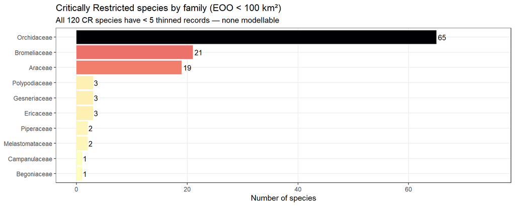

```r
cr_family %>%
  ggplot(aes(x = reorder(family, n), y = n, fill = n)) +
  geom_col() +
  geom_text(aes(label = n), hjust = -0.2, size = 3.5) +
  coord_flip() +
  scale_fill_viridis_c(direction = -1, option = "magma") +
  ylim(0, max(cr_family$n) * 1.15) +
  labs(
    title    = "Critically Restricted species by family (EOO < 100 km²)",
    subtitle = "All 120 CR species have < 5 thinned records — none modellable",
    x        = NULL,
    y        = "Number of species"
  ) +
  theme_bw() +
  theme(legend.position = "none",
        panel.grid.minor = element_blank())
```

All 120 species with EOO < 100 km² have fewer than 5 thinned occurrence records and cannot be modelled. These ultra-rare species — concentrated in Orchidaceae (54%), Bromeliaceae (18%), and Araceae (16%) — will contribute to the sensitivity analysis via their observed occurrence cells only. This finding highlights a fundamental limitation of occurrence-based modelling for the most range-restricted Neotropical epiphytes.

```r
cr_species %>%
  arrange(EOO_km2) %>%
  head(20) %>%
  kable(
    caption = "20 most range-restricted CR species (EOO < 100 km²)",
    digits  = 2
  ) %>%
  kable_styling(full_width = FALSE) %>%
  scroll_box(width = "100%", height = "400px")
```

20 most range-restricted CR species (EOO < 100 km²)

| scientificName | family | genus | n_records | EOO_km2 |
| --- | --- | --- | --- | --- |
| Blakea fuchsioides | Melastomataceae | Blakea | 3 | 0.23 |
| Columnea hiantiflora | Gesneriaceae | Columnea | 3 | 0.88 |
| Epidendrum maduroi | Orchidaceae | Epidendrum | 3 | 1.16 |
| Pleurothallis aspergillum | Orchidaceae | Pleurothallis | 3 | 1.97 |
| Cavendishia pseudopedunculata | Ericaceae | Cavendishia | 3 | 2.48 |
| Epidendrum lopezii | Orchidaceae | Epidendrum | 3 | 3.19 |
| Codonanthopsis anisophylla | Gesneriaceae | Codonanthopsis | 3 | 3.25 |
| Clowesia glaucoglossa | Orchidaceae | Clowesia | 3 | 4.84 |
| Anthurium delannayi | Araceae | Anthurium | 3 | 5.00 |
| Philodendron narinoense | Araceae | Philodendron | 3 | 5.96 |
| Lepanthes pileata | Orchidaceae | Lepanthes | 3 | 6.09 |
| Vriesea leptantha | Bromeliaceae | Vriesea | 3 | 6.40 |
| Lepanthes droseroides | Orchidaceae | Lepanthes | 3 | 6.82 |
| Lepanthes kuijtii | Orchidaceae | Lepanthes | 3 | 6.87 |
| Oncidium dulcineae | Orchidaceae | Oncidium | 3 | 7.04 |
| Anthurium cuasicanum | Araceae | Anthurium | 3 | 7.66 |
| Guzmania kentii | Bromeliaceae | Guzmania | 3 | 8.21 |
| Masdevallia chaparensis | Orchidaceae | Masdevallia | 3 | 8.40 |
| Pleurothallis calogramma | Orchidaceae | Pleurothallis | 3 | 8.65 |
| Aechmea glandulosa | Bromeliaceae | Aechmea | 3 | 9.08 |

# 5 Final Species Counts for Pipeline

```r
tibble(
  Dataset = c(
    "db_modelling_strict.rds",
    "db_modelling_uncertainty.rds",
    "db_thinned_025.rds",
    "spp_endemic_flags.rds",
    "spp_endemics_modellable.rds  [MAIN INPUT]",
    "spp_endemics_unmodellable.rds  [SENSITIVITY]"
  ),
  Records = c(
    format(nrow(db_strict),  big.mark = ","),
    format(nrow(db_unc),     big.mark = ","),
    format(nrow(db_thinned), big.mark = ","),
    "—", "—", "—"
  ),
  Species = c(
    format(n_distinct(db_strict$scientificName),  big.mark = ","),
    format(n_distinct(db_unc$scientificName),     big.mark = ","),
    format(n_distinct(db_thinned$scientificName), big.mark = ","),
    format(nrow(spp_flags), big.mark = ","),
    format(nrow(spp_mod),   big.mark = ","),
    format(nrow(spp_unmod), big.mark = ",")
  )
) %>%
  kable(caption = "Final processed files and species counts") %>%
  kable_styling(full_width = FALSE) %>%
  row_spec(5, bold = TRUE, background = "#e8f4f8")
```

Final processed files and species counts

| Dataset | Records | Species |
| --- | --- | --- |
| db_modelling_strict.rds | 864,624 | 14,979 |
| db_modelling_uncertainty.rds | 845,776 | 14,894 |
| db_thinned_025.rds | 350,059 | 14,894 |
| spp_endemic_flags.rds | — | 14,909 |
| spp_endemics_modellable.rds [MAIN INPUT] | — | 1,861 |
| spp_endemics_unmodellable.rds [SENSITIVITY] | — | 1,714 |

# 6 Methodological Decisions Log

```r
tibble(
  Date = rep("2026-05-11/12", 8),
  Script = c(
    "00_setup",
    "01_01",
    "01_01",
    "01_02",
    "01_03",
    "01_03",
    "01_03",
    "01_03"
  ),
  Decision = c(
    "Working resolution: 0.25° (constrained by LUH2 native resolution)",
    "Retain records with coordinateUncertaintyInMeters = NA",
    "Remove records with coordinateUncertaintyInMeters > 27,500 m",
    "Thinning: 1 record per species per 0.25° cell (set.seed = 123)",
    "EOO: exclude.area = FALSE per IUCN Red List guidelines v4.0",
    "EOO calculated at 0.25° resolution (consistent with modelling)",
    "Main endemism criterion: EOO < 50,000 km² (IUCN B1/Vulnerable)",
    "Sensitivity criterion: EOO < 100,000 km² (broad)"
  ),
  Rationale = c(
    "LUH2 future land use data only available at 0.25°",
    "Excluding NA would bias toward post-2000 records; lose historical diversity",
    "At 0.25° resolution, uncertainty > 27.5 km could misassign grid cell",
    "Removes spatial redundancy; consistent with modelling grid",
    "IUCN: EOO should not be adjusted to exclude unsuitable areas",
    "Consistency between occurrence data resolution and model predictions",
    "Standard IUCN threshold; widely cited; biologically meaningful",
    "Evaluate robustness of hotspot patterns to endemism definition"
  )
) %>%
  kable(caption = "Methodological decisions — data preparation") %>%
  kable_styling(full_width = FALSE) %>%
  scroll_box(width = "100%", height = "400px")
```

Methodological decisions — data preparation

[output not shown]

# 8 Key Findings and Analytical Implications

## 8.1 ESM as the dominant modelling approach

```r
read_csv(here("outputs/evaluation/01_03_model_class_summary.csv"),
         show_col_types = FALSE) %>%
  kable(caption = "Modellable endemic species by modelling approach") %>%
  kable_styling(full_width = FALSE)
```

Modellable endemic species by modelling approach

| model_class | n | pct |
| --- | --- | --- |
| ESM | 1850 | 99.4 |
| SDM | 11 | 0.6 |

Of the 1,861 modellable endemic species, **99.4% (n = 1,850) required the Ensemble of Small Models (ESM) framework** (Lomba et al. 2010; Breiner et al. 2015) due to having fewer than 25 thinned occurrence records. Only 11 species (0.6%) met the threshold for standard ensemble SDM.

The 11 SDM species share a consistent profile: EOO between 20,000–45,000 km², 25–37 thinned records, and a concentration in well-sampled Central American localities (particularly Costa Rica). Araceae dominates this group (4 species: *Anthurium carnosum*, *A. ranchoanum*, *Philodendron thalassicum*, *P. brenesii*), followed by Dryopteridaceae (2 *Elaphoglossum* species).

This near-complete dominance of ESM confirms that range restriction and data scarcity are inseparable in Neotropical vascular epiphytes, and validates the choice of ESM as the primary modelling framework for this analysis.

## 8.2 The unmodellable gap: Critically Restricted species

All 120 species with EOO < 100 km² (Critically Restricted, CR) have fewer than 5 thinned occurrence records and **cannot be modelled with any occurrence-based SDM approach**. These species — concentrated in Orchidaceae (65 spp, 54%), Bromeliaceae (21 spp, 18%), and Araceae (19 spp, 16%) — represent the most range-restricted epiphytes in the Neotropics and are precisely the species of greatest conservation concern.

This finding highlights a fundamental limitation of occurrence-based modelling for conservation: the species most in need of distribution models are the least amenable to being modelled. Their contribution to endemism hotspots will be captured through observed occurrence cells in the sensitivity analysis (`06_05_hs_sensitivity.R`).

## 8.3 Implications for hotspot analysis

Given that 1,714 endemic B1 species are unmodellable (n < 5 records), the main analysis (modelled WE) captures only **52% of endemic B1 species**. The sensitivity analysis comparing modelled vs observed weighted endemism will be essential to assess whether hotspot patterns are robust to this modelling gap.

```r
tibble(
  Component = c(
    "Main analysis (modelled WE)",
    "Sensitivity analysis (observed WE)",
    "Total endemic B1"
  ),
  Species = c(
    nrow(spp_mod),
    nrow(spp_unmod),
    nrow(spp_mod) + nrow(spp_unmod)
  ),
  `% of B1` = round(
    c(nrow(spp_mod), nrow(spp_unmod),
      nrow(spp_mod) + nrow(spp_unmod)) /
      (nrow(spp_mod) + nrow(spp_unmod)) * 100, 1
  ),
  Method = c(
    "SDM/ESM projections → predicted distribution maps",
    "Observed thinned records → occurrence cells only",
    "—"
  )
) %>%
  kable(caption = "Coverage of endemic B1 species in main vs sensitivity analysis") %>%
  kable_styling(full_width = FALSE)
```

Coverage of endemic B1 species in main vs sensitivity analysis

| Component | Species | % of B1 | Method |
| --- | --- | --- | --- |
| Main analysis (modelled WE) | 1861 | 52.1 | SDM/ESM projections → predicted distribution maps |
| Sensitivity analysis (observed WE) | 1714 | 47.9 | Observed thinned records → occurrence cells only |
| Total endemic B1 | 3575 | 100.0 | — |